# Case1- Cyclistic

Shahar Mazur

2022-08-24

# To manipulate date functions

# To create final visualization

# To calculate distances on the map

# To scale th ggplot

knitr::opts_chunk$set(echo = TRUE)

# As Im working on my desktop, making sure the working dir.

## Setting my data dir

```r
getwd()
```

```
## [1] "C:/Users/mazor/Documents/Case1-Cyclistic/Data"
```

```r
setwd("/Users/mazor/Documents/Case1-Cyclistic/Data")
list.files(path = "../Data")
```

```
##  [1] "123.pbix"
##  [2] "202105-divvy-tripdata.csv"
##  [3] "202106-divvy-tripdata.csv"
##  [4] "202107-divvy-tripdata.csv"
##  [5] "202108-divvy-tripdata.csv"
##  [6] "202109-divvy-tripdata.csv"
##  [7] "202110-divvy-tripdata.csv"
##  [8] "202111-divvy-tripdata.csv"
##  [9] "202112-divvy-tripdata.csv"
## [10] "202201-divvy-tripdata.csv"
## [11] "202202-divvy-tripdata.csv"
## [12] "202203-divvy-tripdata.csv"
## [13] "202204-divvy-tripdata.csv"
## [14] "202205-divvy-tripdata.csv"
## [15] "202206-divvy-tripdata.csv"
```

[output cut: 22 more lines]

# Reading in the entire Dataset - 1 Year’s worth of traveling data

```r
tripdata_202107 <- read.csv("../data/202107-divvy-tripdata.csv")
tripdata_202108 <- read.csv("../data/202108-divvy-tripdata.csv")
tripdata_202109 <- read.csv("../data/202109-divvy-tripdata.csv")
tripdata_202110 <- read.csv("../data/202110-divvy-tripdata.csv")
tripdata_202111 <- read.csv("../data/202111-divvy-tripdata.csv")
tripdata_202112 <- read.csv("../data/202112-divvy-tripdata.csv")
tripdata_202201 <- read.csv("../data/202201-divvy-tripdata.csv")
tripdata_202202 <- read.csv("../data/202202-divvy-tripdata.csv")
tripdata_202203 <- read.csv("../data/202203-divvy-tripdata.csv")
tripdata_202204 <- read.csv("../data/202204-divvy-tripdata.csv")
tripdata_202205 <- read.csv("../data/202205-divvy-tripdata.csv")
tripdata_202206 <- read.csv("../data/202206-divvy-tripdata.csv")
```

#……………..# #Checking My Data # #……………..# # Checking coulmn names are identical before joining all data

```r
colnames(tripdata_202107)
```

```
##  [1] "ride_id"            "rideable_type"      "started_at"
##  [4] "ended_at"           "start_station_name" "start_station_id"
##  [7] "end_station_name"   "end_station_id"     "start_lat"
## [10] "start_lng"          "end_lat"            "end_lng"
## [13] "member_casual"
```

```r
colnames(tripdata_202108)
```

```
##  [1] "ride_id"            "rideable_type"      "started_at"
##  [4] "ended_at"           "start_station_name" "start_station_id"
##  [7] "end_station_name"   "end_station_id"     "start_lat"
## [10] "start_lng"          "end_lat"            "end_lng"
## [13] "member_casual"
```

```r
colnames(tripdata_202109)
```

```
##  [1] "ride_id"            "rideable_type"      "started_at"
##  [4] "ended_at"           "start_station_name" "start_station_id"
##  [7] "end_station_name"   "end_station_id"     "start_lat"
## [10] "start_lng"          "end_lat"            "end_lng"
## [13] "member_casual"
```

```r
colnames(tripdata_202110)
```

```
##  [1] "ride_id"            "rideable_type"      "started_at"
##  [4] "ended_at"           "start_station_name" "start_station_id"
##  [7] "end_station_name"   "end_station_id"     "start_lat"
## [10] "start_lng"          "end_lat"            "end_lng"
## [13] "member_casual"
```

```r
colnames(tripdata_202111)
```

```
##  [1] "ride_id"            "rideable_type"      "started_at"
##  [4] "ended_at"           "start_station_name" "start_station_id"
##  [7] "end_station_name"   "end_station_id"     "start_lat"
## [10] "start_lng"          "end_lat"            "end_lng"
## [13] "member_casual"
```

```r
colnames(tripdata_202112)
```

```
##  [1] "ride_id"            "rideable_type"      "started_at"
##  [4] "ended_at"           "start_station_name" "start_station_id"
##  [7] "end_station_name"   "end_station_id"     "start_lat"
## [10] "start_lng"          "end_lat"            "end_lng"
## [13] "member_casual"
```

```r
colnames(tripdata_202201)
```

```
##  [1] "ride_id"            "rideable_type"      "started_at"
##  [4] "ended_at"           "start_station_name" "start_station_id"
##  [7] "end_station_name"   "end_station_id"     "start_lat"
## [10] "start_lng"          "end_lat"            "end_lng"
## [13] "member_casual"
```

```r
colnames(tripdata_202202)
```

```
##  [1] "ride_id"            "rideable_type"      "started_at"
##  [4] "ended_at"           "start_station_name" "start_station_id"
##  [7] "end_station_name"   "end_station_id"     "start_lat"
## [10] "start_lng"          "end_lat"            "end_lng"
## [13] "member_casual"
```

```r
colnames(tripdata_202203)
```

```
##  [1] "ride_id"            "rideable_type"      "started_at"
##  [4] "ended_at"           "start_station_name" "start_station_id"
##  [7] "end_station_name"   "end_station_id"     "start_lat"
## [10] "start_lng"          "end_lat"            "end_lng"
## [13] "member_casual"
```

```r
colnames(tripdata_202204)
```

```
##  [1] "ride_id"            "rideable_type"      "started_at"
##  [4] "ended_at"           "start_station_name" "start_station_id"
##  [7] "end_station_name"   "end_station_id"     "start_lat"
## [10] "start_lng"          "end_lat"            "end_lng"
## [13] "member_casual"
```

```r
colnames(tripdata_202205)
```

```
##  [1] "ride_id"            "rideable_type"      "started_at"
##  [4] "ended_at"           "start_station_name" "start_station_id"
##  [7] "end_station_name"   "end_station_id"     "start_lat"
## [10] "start_lng"          "end_lat"            "end_lng"
## [13] "member_casual"
```

```r
colnames(tripdata_202206)
```

```
##  [1] "ride_id"            "rideable_type"      "started_at"
##  [4] "ended_at"           "start_station_name" "start_station_id"
##  [7] "end_station_name"   "end_station_id"     "start_lat"
## [10] "start_lng"          "end_lat"            "end_lng"
## [13] "member_casual"
```

# Joining all data to one dataset to make future processing more simple

```r
Total_Trip_Data <- bind_rows(tripdata_202107
                             ,tripdata_202108
                             ,tripdata_202109
                             ,tripdata_202110
                             ,tripdata_202111
                             ,tripdata_202112
                             ,tripdata_202201
                             ,tripdata_202202
                             ,tripdata_202203
                             ,tripdata_202204
                             ,tripdata_202205
                             ,tripdata_202206)
```

```r
print(unique(Total_Trip_Data$rideable_type))
```

```
## [1] "docked_bike"   "classic_bike"  "electric_bike"
```

### Consistent with 3 types of bikes - “docked_bike” “classic_bike” “electric_bike” - No Nulls

```r
print(unique(Total_Trip_Data$member_casual))
```

```
## [1] "casual" "member"
```

### Data contain a lot of un-needed data, as charging stations, repair stations, mobile stations .

```r
print(mean(Total_Trip_Data$start_lat))
```

```
## [1] 41.90058
```

```r
print(mean(Total_Trip_Data$start_lng))
```

```
## [1] -87.64718
```

```r
print(mean(Total_Trip_Data$end_lat))
```

```
## [1] NA
```

```r
print(mean(Total_Trip_Data$end_lng))
```

```
## [1] NA
```

##### mean(Total_Trip_Data$end_lng came out as NA ##### mean(Total_Trip_Data$end_lat came out as NA

##### A quick check to see if there are NULLs in a numeric data frames

##### It shows some of the bikes never arrived to an end station (theft, broke) either way the data will interfere with our results and should be removed.

##### 774 bikes has not arrived to an end station by members.

##### 3545 bikes has not arrived to an end station by casual users.

##### Total of 4319 bikes has not arrived to an end station.

# Organizing My Data

```r
Total_Trip_Data <- na.omit(Total_Trip_Data)
```

### extract year, month, date, day of week .

```r
Total_Trip_Data <- Total_Trip_Data %>%
  mutate(year = format(as.Date(start_time), "%Y")) %>%
  mutate(month = format(as.Date(start_time), "%B")) %>%
  mutate(date = format(as.Date(start_time), "%d")) %>%
  mutate(day_of_week = format(as.Date(start_time), "%A")) %>%
  mutate(ride_length = difftime(end_time, start_time))

Total_Trip_Data <- Total_Trip_Data %>%
  mutate(ride_length = as.numeric(ride_length))
```

# Adding a column to calculate each trip duration

```r
Total_Trip_Data <- mutate(Total_Trip_Data, tripduration = int_length(interval(ymd_hms(Total_Trip_Data$start_time), ymd_hms(Total_Trip_Data$end_time))))
```

# Calculating aerial distance of the trip.

```r
Total_Trip_Data$Ariel_distance <- distGeo(matrix(c(Total_Trip_Data$start_lng, Total_Trip_Data$start_lat), ncol = 2), matrix(c(Total_Trip_Data$end_lng, Total_Trip_Data$end_lat), ncol = 2))


Total_Trip_Data <- Total_Trip_Data[!(Total_Trip_Data$Ariel_distance <= 0),]
```

# Cleaning rides that were picked up and returned to the same station.

#### Cleared 366,276 rows (this is a data collection issue)

```r
Total_Trip_Data <- Total_Trip_Data[!(Total_Trip_Data$Ariel_distance >=30000),]
```

## Cleaning unusual rides, over 30KM (cleared 10 rows)

```r
Total_Trip_Data <- Total_Trip_Data[!(Total_Trip_Data$tripduration <= 0),]
```

## Cleaning rows with issue as trip duration =<0 , cleared 484 rows

# Creating Backup number 2

## Analyzing

```r
Total_Trip_Data %>%
  group_by(rideable_type) %>%
  summarise(ride_count = length(ride_id), ride_percentage = (length(ride_id) / nrow(Total_Trip_Data)) * 100)
```

```
## # A tibble: 3 × 3
##   rideable_type ride_count ride_percentage
##   <chr>              <int>           <dbl>
## 1 classic_bike     2993916           54.2
## 2 docked_bike       206929            3.74
## 3 electric_bike    2327396           42.1
```

# what is “docked_bike” ?

### Contacted Divvy , the answer was that Docked_bike are equal to Classic_bike.

```r
Total_Trip_Data['rideable_type'][Total_Trip_Data['rideable_type'] =="docked_bike"] <- "classic_bike"
print(unique(Total_Trip_Data$rideable_type))
```

```
## [1] "classic_bike"  "electric_bike"
```

### Corrected to 2 types of bikes - “classic_bike” “electric_bike” - No Nulls

```r
Total_Trip_Data %>%
  group_by(member_casual) %>%
  summarise(ride_count = length(ride_id), ride_percentage = (length(ride_id) / nrow(Total_Trip_Data)) * 100)
```

```
## # A tibble: 2 × 3
##   member_casual ride_count ride_percentage
##   <chr>              <int>           <dbl>
## 1 casual           2345925            42.4
## 2 member           3182316            57.6
```

```r
Total_Trip_Data %>%
  group_by(member_casual) %>%
  summarise(longest_ride_MINUTES = max(tripduration/60),Average_ride_MINUTES = mean(tripduration/60),Shortest_ride_MINUTES = min(tripduration/60))
```

```
## # A tibble: 2 × 4
##   member_casual longest_ride_MINUTES Average_ride_MINUTES Shortest_ride_MINUTES
##   <chr>                        <dbl>                <dbl>                 <dbl>
## 1 casual                      49107.                 24.9                0.0167
## 2 member                       1500.                 12.8                0.0167
```

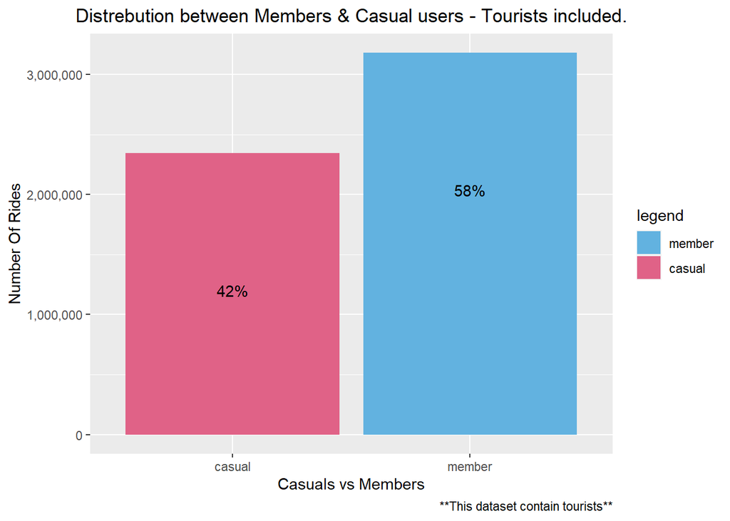

```r
Total_Trip_Data %>%
ggplot(mapping = aes(x = member_casual, fill=member_casual)) +
  geom_bar() +
  labs( x="Casuals vs Members", y="Number Of Rides", title= "Distrebution between Members & Casual users - Tourists included.",alt = "User Type", caption = "**This dataset contain tourists**") +
  scale_y_continuous(labels = comma) +
  scale_fill_manual("legend", values = c("member" = "#62B2E0", "casual" = "#E06287")) +
  theme(plot.title = element_text(hjust = 0.5)) +
  geom_text(aes(label = scales::percent((..count..)/sum(..count..))), stat = "count", vjust = 12, colour = "Black")
```

## 42.4% ## 57.6%

## Sorting “day_of_week” by the days of the week

```r
Total_Trip_Data$day_of_week <- factor(Total_Trip_Data$day_of_week,
                               levels = as.character(wday(c(2:7,1), label=TRUE, abbr=FALSE)))
```

## Sorting “month” by the months of the year

```r
Total_Trip_Data$month <- factor(Total_Trip_Data$month,
                                      levels = as.character(month(c(7:12,1:6), label=TRUE, abbr=FALSE)))
```

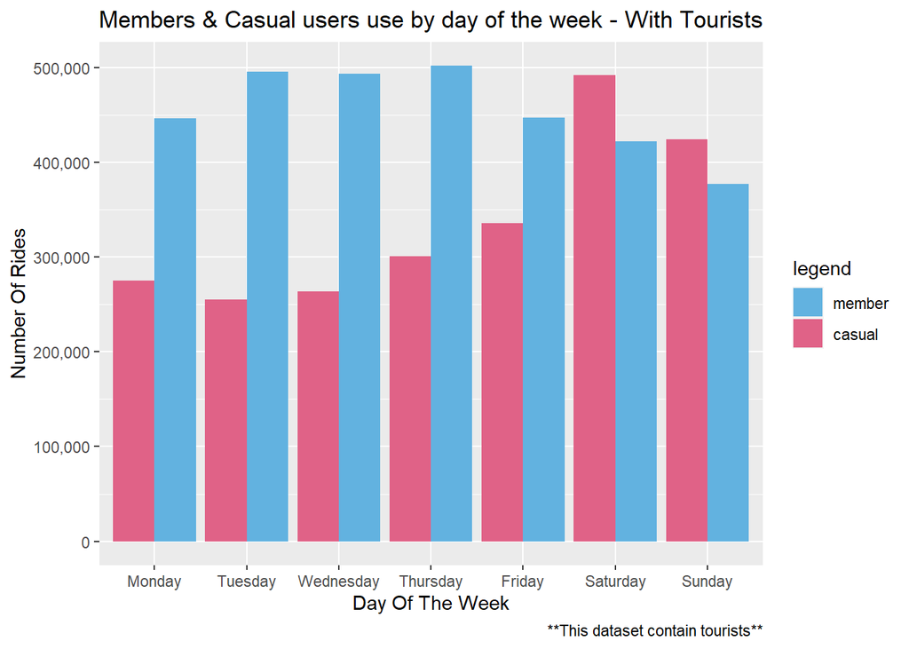

```r
ggplot(Total_Trip_Data, aes(x=day_of_week,fill = member_casual)) +
  geom_bar(position = "dodge") +
  scale_y_continuous(labels = comma)+
  theme(plot.title = element_text(hjust = 0.5)) +
  labs( x="Day Of The Week", y="Number Of Rides", title= "Members & Casual users use by day of the week - With Tourists",alt = "User Type", caption = "**This dataset contain tourists**") +
  scale_fill_manual("legend", values = c("member" = "#62B2E0", "casual" = "#E06287"))
```

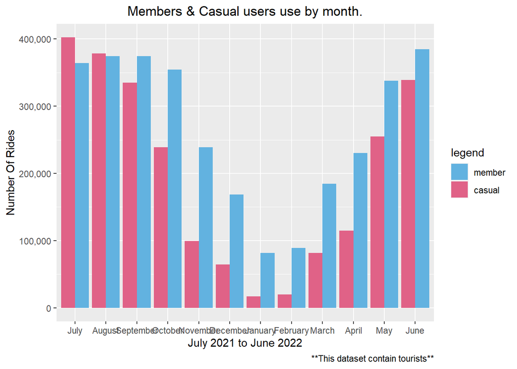

```r
ggplot(Total_Trip_Data, aes(x=month,fill = member_casual)) +
  geom_bar(position = "dodge") +
  scale_y_continuous(labels = comma)+
  theme(plot.title = element_text(hjust = 0.5)) +
  scale_fill_manual("legend", values = c("member" = "#62B2E0", "casual" = "#E06287")) +
  labs(x="July 2021 to June 2022", y="Number Of Rides", title= "Members & Casual users use by month.",caption = "**This dataset contain tourists**")
```

### Analyzing these 2 tablets shows us there are too many tourists in the dataset, and the should not be considered in the research.

# Creating a backup for the cleaning process

```r
Total_Trip_Data -> Total_Trip_Data_temp2
write.csv(Total_Trip_Data,"C:\\Users\\mazor\\Documents\\Case1-Cyclistic\\Data\\Final_Dataset_with_tourists.csv", row.names = FALSE)
```

# Removing stations that are considered by the company as ” for tourism”

```r
Total_Trip_Data_no_tourists <- Total_Trip_Data[!(Total_Trip_Data$end_station_name=="Streeter Dr & Grand Ave"
                                                  | Total_Trip_Data$end_station_name=="Ft Dearborn Dr & 31st St"
                                                  | Total_Trip_Data$end_station_name=="South Shore Dr & 71st St"
                                                  | Total_Trip_Data$end_station_name=="Museum of Science and Industry"
                                                  | Total_Trip_Data$end_station_name=="Shore Dr & 55th St"
                                                  | Total_Trip_Data$end_station_name=="Fort Dearborn Dr & 31st St"
                                                  | Total_Trip_Data$end_station_name=="Burnham Harbor"
                                                  | Total_Trip_Data$end_station_name=="Shedd Aquarium"
                                                  | Total_Trip_Data$end_station_name=="Field Museum"
                                                  | Total_Trip_Data$end_station_name=="Adler Planetarium"
                                                  | Total_Trip_Data$end_station_name=="Lake Shore Dr & Monroe St"
                                                  | Total_Trip_Data$end_station_name=="DuSable Harbor"
                                                  | Total_Trip_Data$end_station_name=="Lake Park Ave & 53rd St"
                                                 | Total_Trip_Data$end_station_name=="Lake Shore Dr & North Blvd"
                                                 | Total_Trip_Data$end_station_name=="Clark St & Armitage Ave"
                                                 | Total_Trip_Data$end_station_name=="Cannon Dr & Fullerton Ave"
                                                 | Total_Trip_Data$end_station_name=="Lake Shore Dr & Belmont Ave"
                                                 | Total_Trip_Data$end_station_name=="Montrose Harbor"
                                                 | Total_Trip_Data$end_station_name=="Michigan Ave & Oak St"
                                                 | Total_Trip_Data$end_station_name=="Marshfield Ave & Courtland St"
                                                 | Total_Trip_Data$end_station_name=="Damen Ave & Courtland St"
                                                 | Total_Trip_Data$end_station_name=="Milwaukee Ave & Wabansia St"
                                                 | Total_Trip_Data$end_station_name=="Western Ave & Winnebago Ave"
                                                 | Total_Trip_Data$end_station_name=="Albany Ave & Bloomingdale Ave"
                                                 | Total_Trip_Data$end_station_name=="Theater on the Lake"
                                                 | Total_Trip_Data$start_station_name=="Streeter Dr & Grand Ave"
                                                 | Total_Trip_Data$start_station_name=="Ft Dearborn Dr & 31st St"
                                                 | Total_Trip_Data$start_station_name=="South Shore Dr & 71st St"
                                                 | Total_Trip_Data$start_station_name=="Museum of Science and Industry"
                                                 | Total_Trip_Data$start_station_name=="Shore Dr & 55th St"
                                                 | Total_Trip_Data$start_station_name=="Fort Dearborn Dr & 31st St"
                                                 | Total_Trip_Data$start_station_name=="Burnham Harbor"
                                                 | Total_Trip_Data$start_station_name=="Shedd Aquarium"
                                                 | Total_Trip_Data$start_station_name=="Field Museum"
                                                 | Total_Trip_Data$start_station_name=="Adler Planetarium"
                                                 | Total_Trip_Data$start_station_name=="Lake Shore Dr & Monroe St"
                                                 | Total_Trip_Data$start_station_name=="DuSable Harbor"
                                                 | Total_Trip_Data$start_station_name=="Lake Park Ave & 53rd St"
                                                 | Total_Trip_Data$start_station_name=="Lake Shore Dr & North Blvd"
                                                 | Total_Trip_Data$start_station_name=="Clark St & Armitage Ave"
                                                 | Total_Trip_Data$start_station_name=="Cannon Dr & Fullerton Ave"
                                                 | Total_Trip_Data$start_station_name=="Lake Shore Dr & Belmont Ave"
                                                 | Total_Trip_Data$start_station_name=="Montrose Harbor"
                                                 | Total_Trip_Data$start_station_name=="Michigan Ave & Oak St"
                                                 | Total_Trip_Data$start_station_name=="Marshfield Ave & Courtland St"
                                                 | Total_Trip_Data$start_station_name=="Damen Ave & Courtland St"
                                                 | Total_Trip_Data$start_station_name=="Milwaukee Ave & Wabansia St"
                                                 | Total_Trip_Data$start_station_name=="Western Ave & Winnebago Ave"
                                                 | Total_Trip_Data$start_station_name=="Albany Ave & Bloomingdale Ave"
                                                 | Total_Trip_Data$start_station_name=="Theater on the Lake"),]
```

```r
Total_Trip_Data_no_tourists <- Total_Trip_Data_no_tourists[!(Total_Trip_Data_no_tourists$Ariel_distance >=30000),]
Total_Trip_Data_no_tourists <- Total_Trip_Data_no_tourists[!(Total_Trip_Data_no_tourists$tripduration <= 0),]
```

#### This is the last version and change to the dataframe, I work on a laptop so to clear out memory space I will export my dataset into a CSV file, clear the workframe are from old datasets and re-load only what I need for graphic use.